# Dynamiques spatio-temporelles des oiseaux communs à La Réunion

Stage M1 BEE - CESCO-MNHN | STOC-EPS 2014-2024

Auteur·rice

Mylène Vitry

Date de publication

24 septembre 2026

## 1 Introduction

Le Suivi Temporel des Oiseaux Communs (STOC-EPS) est un programme de sciences participatives coordonné par le Muséum National d’Histoire Naturelle (MNHN) et permettant de suivre l’abondance des oiseaux communs. À La Réunion, ce suivi porte, après nettoyage, sur **73 sites** et **730 points d’écoute** (2014-2024, 11 ans).

Ce rapport présente les résultats des analyses de **tendances temporelles d’abondance apparente** par milieu, en lien avec l’**usage apparent d’habitat** par groupe et par espèces.

## 2 Données

### 2.1 Jeu de données STOC-EPS La Réunion

| Indicateur | Valeur |
| --- | --- |
| Période | 2014-2024 (11 ans) |
| Nombre de sites | 73 |
| Nombre de points d'écoute | 730 |
| Nombre d'espèces (hors migrateurs/marins) | 37 |
| Nombre d'observateurs | 101 |
| Stabilité de l'effort (CV* des points/an) | 3.2 % |

*Effort d’échantillonnage stable ~ CV < 10%

### 2.2 Classification des habitats

Chaque milieu regroupe plusieurs sous-habitats, détaillés dans le tableau ci-dessous :

Composition des habitats STOC-EPS La Réunion

| Milieu | Sous-habitat | N points | % du milieu |
| --- | --- | --- | --- |
| Forêt indigène (284 pts) | Foret de montagne et Tamarinaie | 105 | 37.0 |
|  | Foret de basse altitude | 82 | 28.9 |
|  | Vegetation de haute altitude | 47 | 16.5 |
|  | Foret de moyenne altitude | 41 | 14.4 |
|  | Autres habitats naturels | 9 | 3.2 |
| Agriculture (142 pts) | Canne a sucre | 95 | 66.9 |
|  | Agriculture - Elevage | 47 | 33.1 |
| Forêt exotique (138 pts) | Foret secondaire/envahie | 99 | 71.7 |
|  | Habitats de faibles etendues | 39 | 28.3 |
| Urbain (115 pts) | Urbain | 115 | 100.0 |
| Autre vég. indigène (49 pts) | Autres habitats naturels | 25 | 51.0 |
|  | Habitats de faibles etendues | 14 | 28.6 |
|  | Foret de moyenne altitude | 6 | 12.2 |
|  | Foret de basse altitude | 4 | 8.2 |

### 2.3 Carte des points STOC-EPS

[interactive chart not shown]

### 2.4 Composition de la communauté

| Statut | N espèces | N individus | % espèces | % individus |
| --- | --- | --- | --- | --- |
| Introduits | 24 | 78961 | 64.9 | 62.3 |
| Natifs (endémiques + indigènes) | 13 | 47845 | 35.1 | 37.7 |

Détail des natifs : endémiques vs indigènes

| Statut détaillé | N espèces | N individus | % espèces | % individus |
| --- | --- | --- | --- | --- |
| Endémique | 7 | 40334 | 53.8 | 84.3 |
| Indigène | 6 | 7511 | 46.2 | 15.7 |

### 2.5 Espèces les plus abondantes et communes

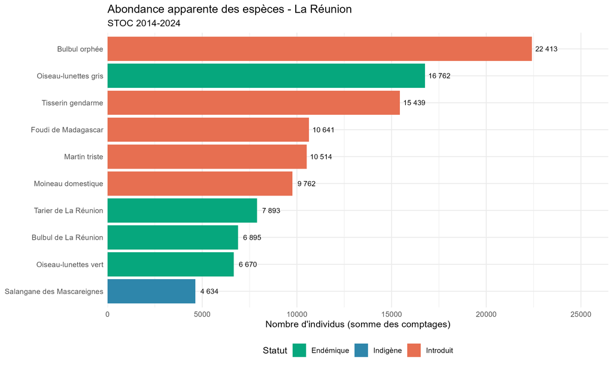

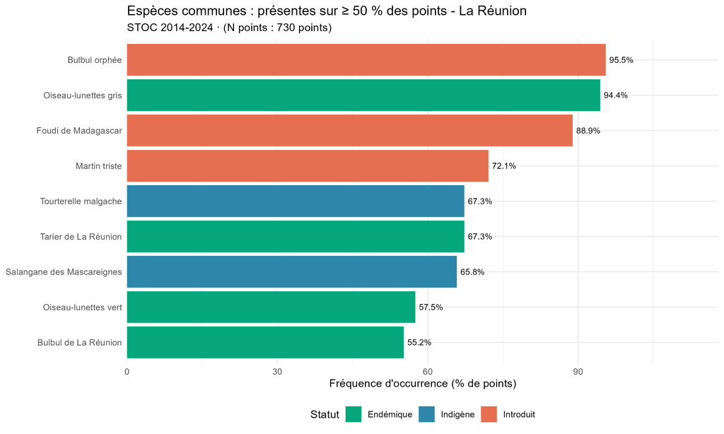

Ces classements utilisent l’**abondance apparente** : les oiseaux ne sont pas tous détectés de la même façon selon l’espèce et le milieu (détectabilité non corrigée), et un même point est recompté chaque année pendant 11 ans (les comptages ne sont donc pas indépendants). Le **nombre d’espèces** (richesse) est l’indicateur le plus fiable, tandis que le nombre de contacts et d’individus donne surtout un ordre de grandeur et sont à interpréter avec prudence.

### 2.6 Cartes de répartition par espèce

La taille des cercles est proportionnelle au logarithme de l’abondance apparente moyenne par visite (échelle commune à toutes les espèces).

[interactive chart not shown]

## 3 Usage apparent d’habitat

Analyse restreinte aux espèces communes (critère de sélection fidèle à Vimont *et al.* 2025 : ≥ 5 sites/an en moyenne, ≥ 2 habitats), hors espèces aériennes et marines. L’**usage relatif** (IRR) compare l’abondance d’une espèce dans un habitat à la moyenne de ses habitats : **> ×1 = sur-utilisation, < ×1 = évitement, = ×1 = usage moyen**.

**Significativité** : intervalle de confiance à 95 % **exclut ×1** (usage moyen). Au niveau des groupes, les p-values sont corrigées pour les tests multiples (**p FDR**, Benjamini-Hochberg) : **p FDR < 0,05** = significatif après correction.

### 3.1 Par groupe

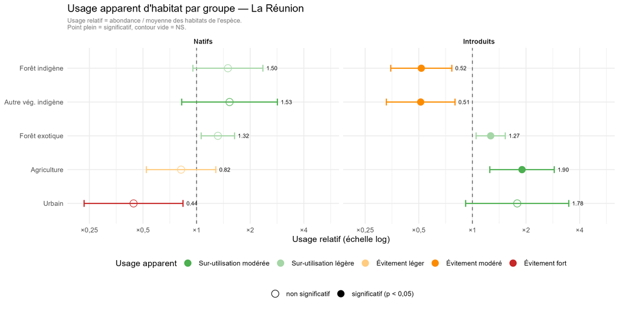

Usage apparent d'habitat par groupe (I² = hétérogénéité inter-espèces)

| Groupe | Habitat | Usage relatif | Lecture | I² | p (FDR) |
| --- | --- | --- | --- | --- | --- |
| Introduits | Agriculture | ×1.90 [1.25–2.88] | sur-utilise | 95 % | 0.014 |
|  | Autre vég. indigène | ×0.51 [0.33–0.80] | évite | 88 % | 0.014 |
|  | Forêt exotique | ×1.27 [1.05–1.53] | sur-utilise légèrement | 73 % | 0.025 |
|  | Forêt indigène | ×0.52 [0.35–0.77] | évite | 91 % | 0.014 |
|  | Urbain | ×1.78 [0.92–3.48] | usage moyen (NS) | 98 % | 0.080 |
| Natifs | Agriculture | ×0.82 [0.52–1.28] | usage moyen (NS) | 94 % | 0.320 |
|  | Autre vég. indigène | ×1.53 [0.82–2.84] | usage moyen (NS) | 95 % | 0.180 |
|  | Forêt exotique | ×1.32 [1.06–1.63] | usage moyen (NS) | 84 % | 0.051 |
|  | Forêt indigène | ×1.50 [0.95–2.36] | usage moyen (NS) | 96 % | 0.120 |
|  | Urbain | ×0.44 [0.23–0.84] | usage moyen (NS) | 95 % | 0.051 |

Les **introduits** sur-utilisent les milieux anthropisés et la forêt exotique et évitent les milieux indigènes ; les **natifs** montrent le patron inverse. Une très forte hétérogénéité inter-espèces (I² élevés) est observée.

### 3.2 Par espèce

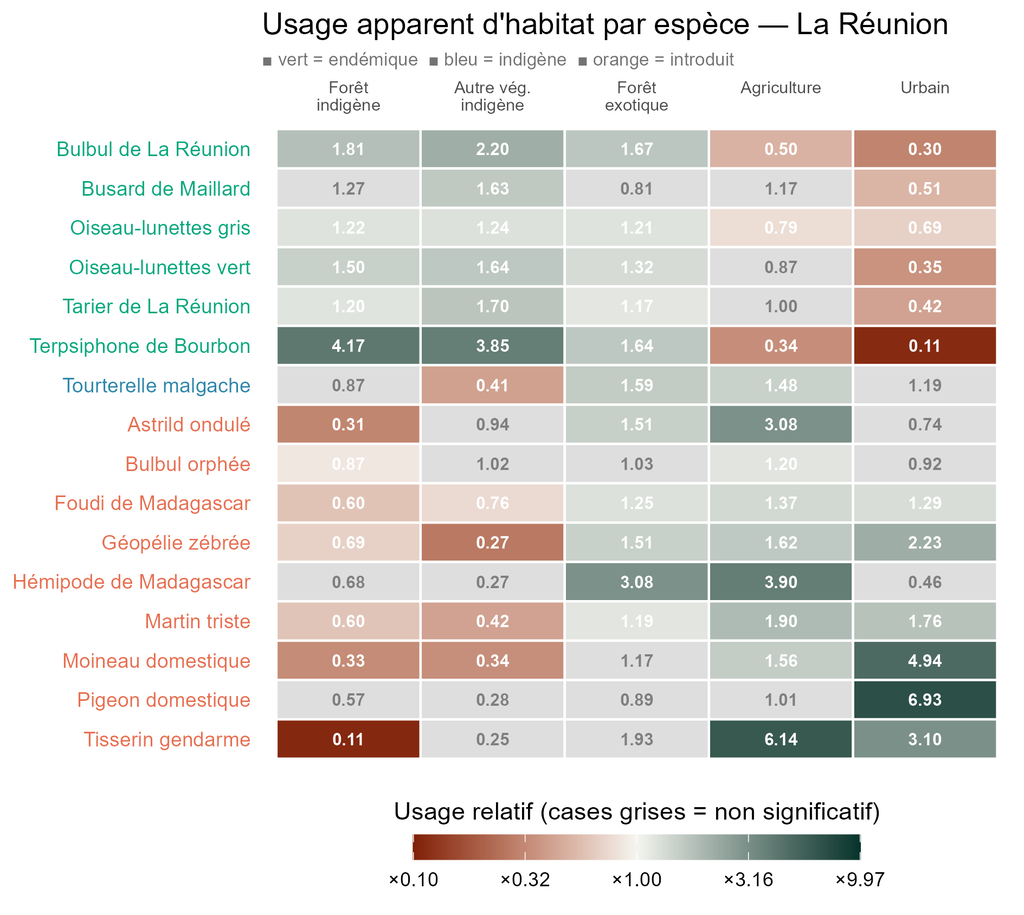

## 4 Tendances temporelles d’abondance apparente

Tendances estimées par la Routine GLMM du MNHN (Vimont *et al.* 2025), classées selon ses 8 catégories : Augmentation forte, Augmentation modérée à forte, Augmentation modérée, Stable, Déclin modéré, Déclin modéré à fort, Déclin fort, Incertain.

### 4.2 Par milieu

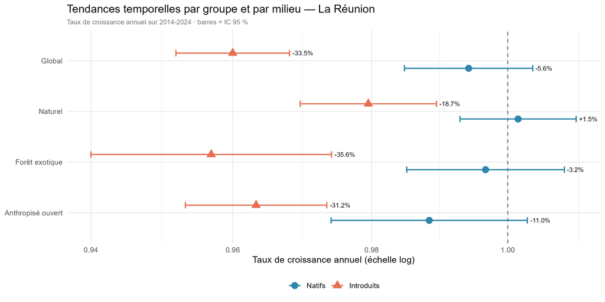

### 4.3 Croisement usage ↔︎ tendance

Croisement descriptif (aucun test) : usage apparent (agrégé par milieu) × tendance (usage relatif moyen sans IC)

| Groupe | Milieu | Usage relatif moyen | Tendance |
| --- | --- | --- | --- |
| Introduits | Anthropise ouvert | ×1.84 | -31.2 % |
|  | Forêt exotique | ×1.27 | -35.6 % |
|  | Naturel | ×0.51 | -18.7 % |
| Natifs | Anthropise ouvert | ×0.60 | -11.0 % |
|  | Forêt exotique | ×1.32 | -3.2 % |
|  | Naturel | ×1.51 | +1.5 % |

Les introduits déclinent davantage dans les milieux qu’ils sur-utilisent (anthropisé, forêt exotique), tandis que les natifs se maintiennent mieux dans leur habitat favori (naturel).

## 5 Fiches espèces

Au total, **17 espèces** ont été analysées (usage et tendance estimés), dont :

- **8 natives** (6 endémiques, 2 indigènes) : 1 en augmentation, 4 en déclin, 2 stables et 1 incertaines ;
- **9 introduites** : 0 en augmentation, 7 en déclin, 1 stables et 1 incertaines.

### 5.1 Tourterelle malgache — Augmentation modérée à forte (+35.1% global)

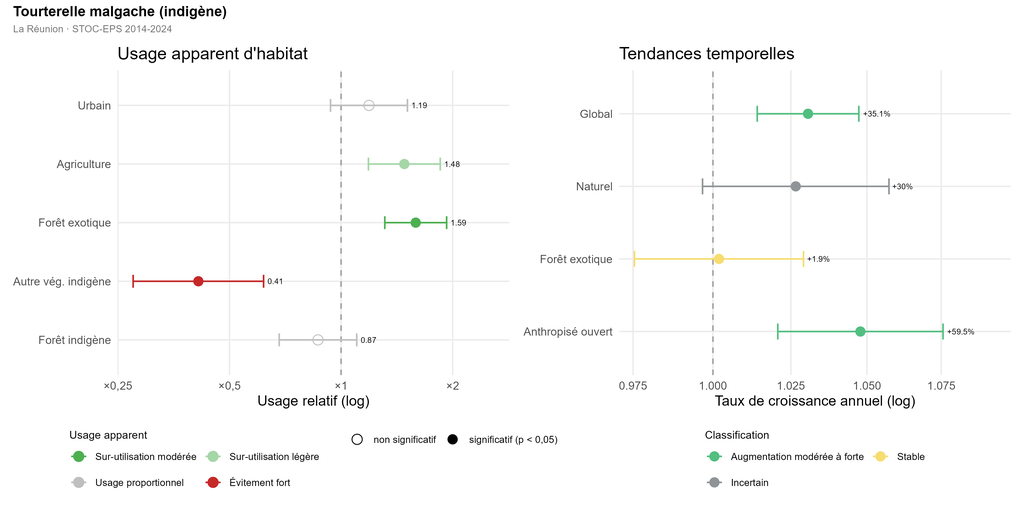

### 5.2 Terpsiphone de Bourbon — Déclin modéré (-27% global)

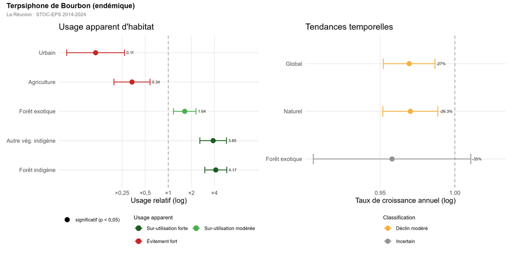

### 5.3 Oiseau-lunettes vert — Déclin modéré (-13.6% global)

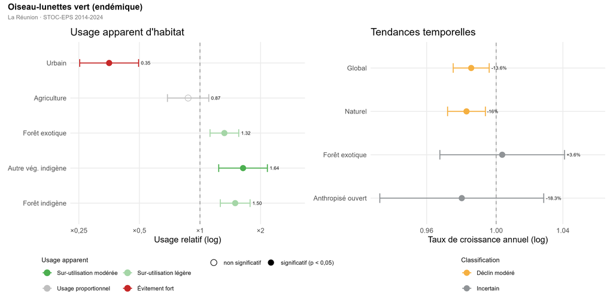

### 5.4 Tarier de La Réunion — Déclin modéré (-11.1% global)

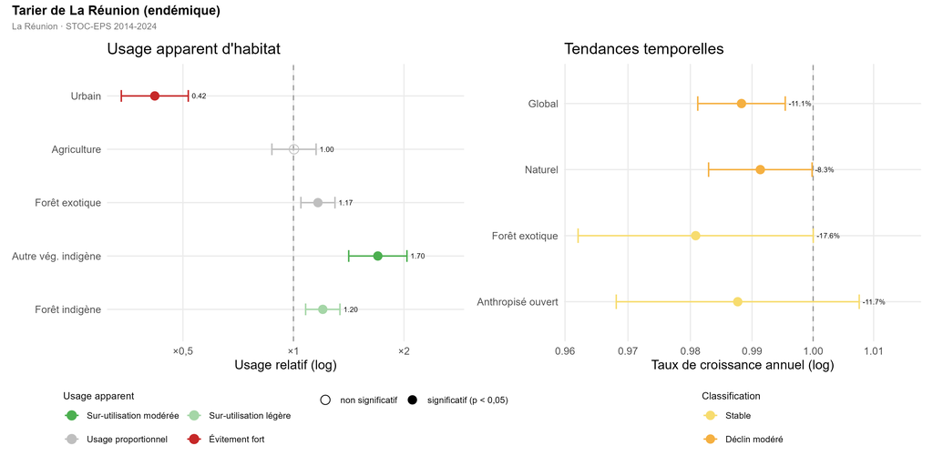

### 5.5 Oiseau-lunettes gris — Déclin modéré (-8.2% global)

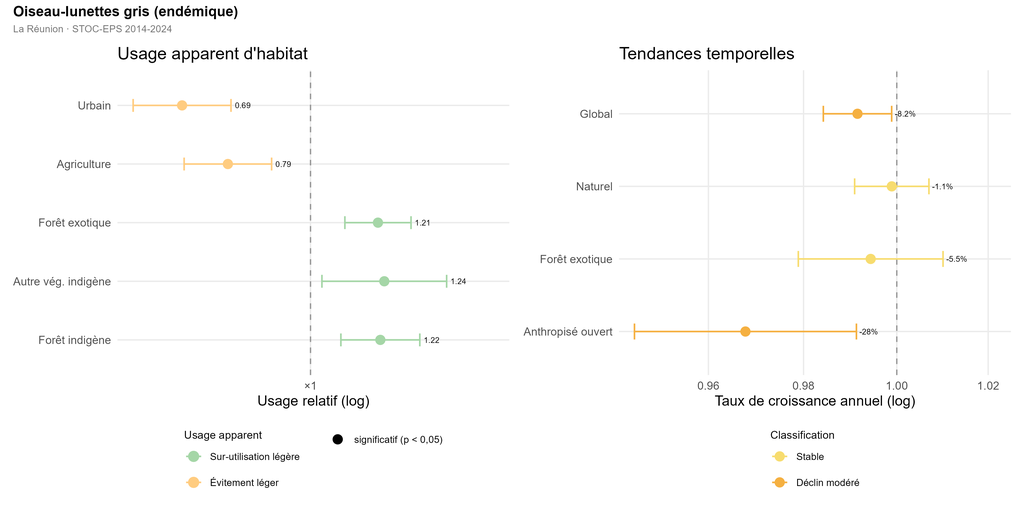

### 5.6 Astrild ondulé — Déclin fort (-68.2% global)

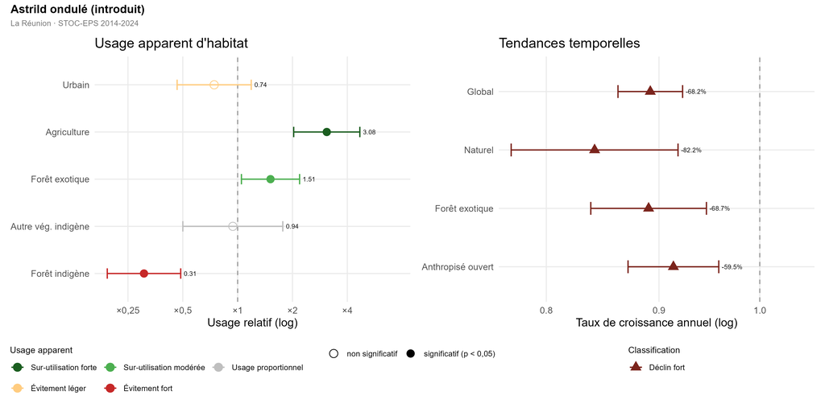

### 5.7 Tisserin gendarme — Déclin modéré à fort (-49.5% global)

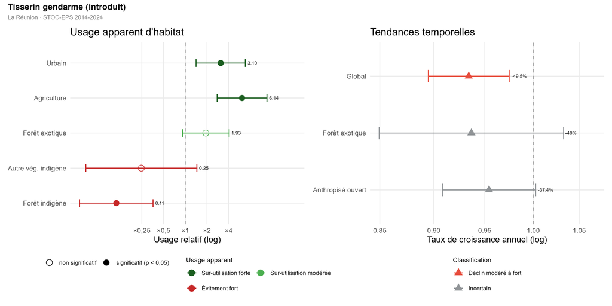

### 5.8 Pigeon domestique — Déclin modéré à fort (-34.6% global)

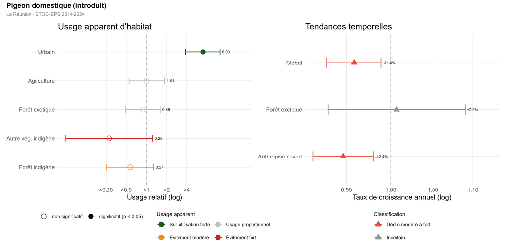

### 5.9 Moineau domestique — Déclin modéré à fort (-34.1% global)

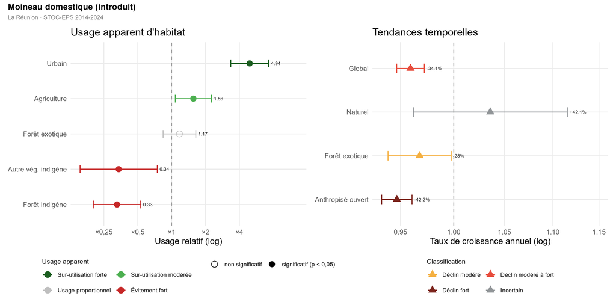

### 5.10 Géopélie zébrée — Déclin modéré (-28.7% global)

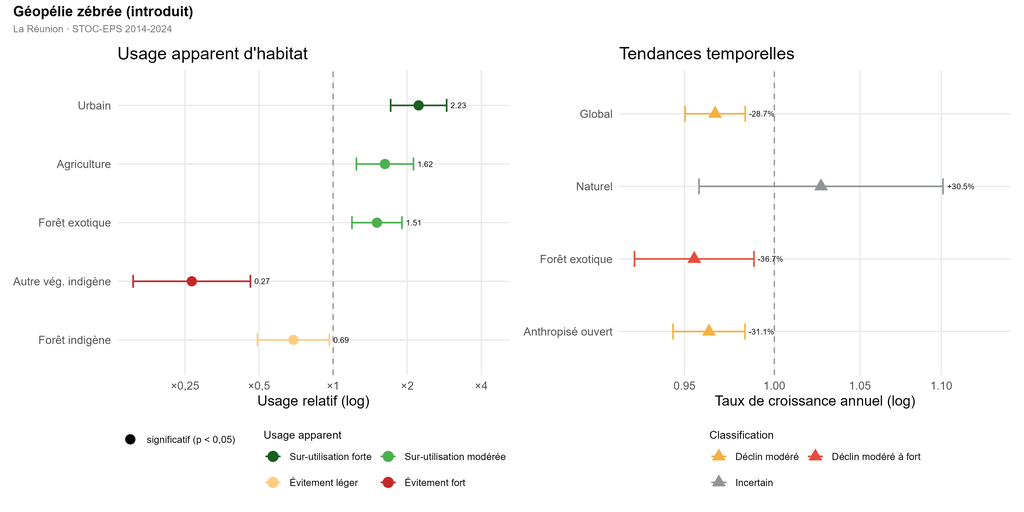

### 5.11 Bulbul orphée — Déclin modéré (-12.9% global)

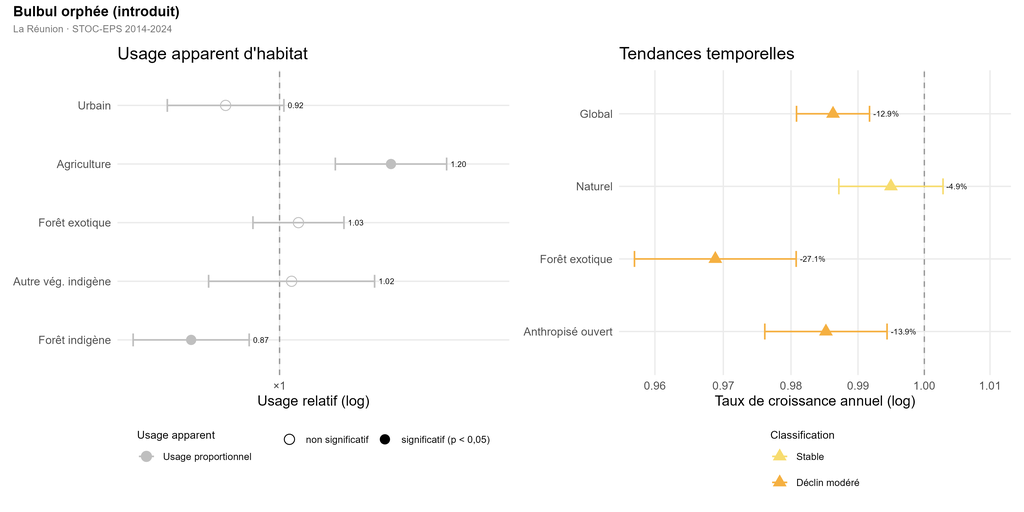

### 5.12 Foudi de Madagascar — Déclin modéré (-8.8% global)

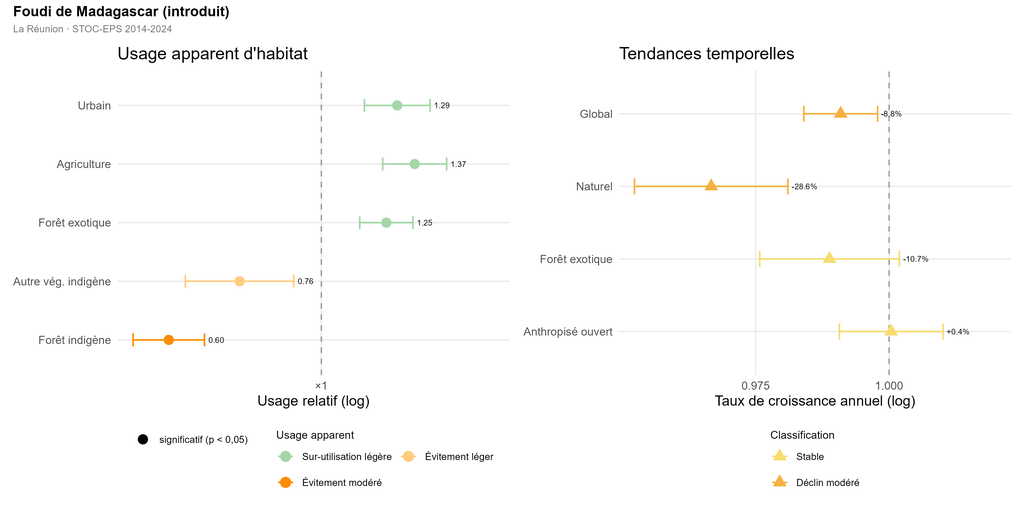

### 5.13 Bulbul de La Réunion — Stable (-8.3% global)

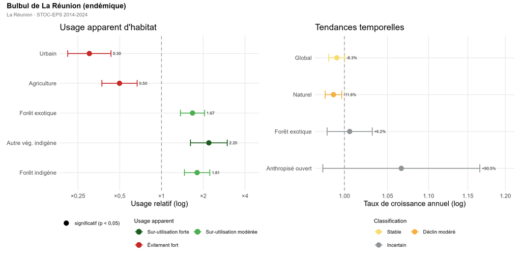

### 5.14 Salangane des Mascareignes — Stable (-15.7% global)

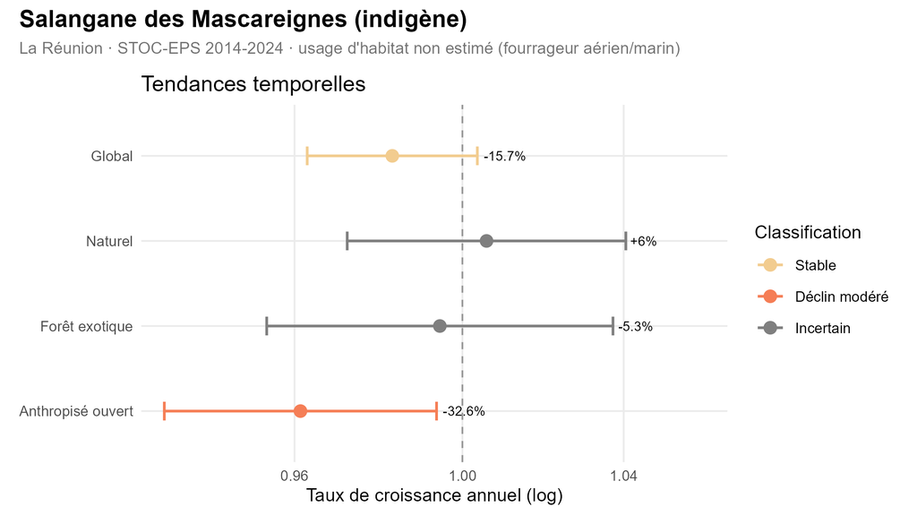

### 5.15 Martin triste — Stable (-3.9% global)

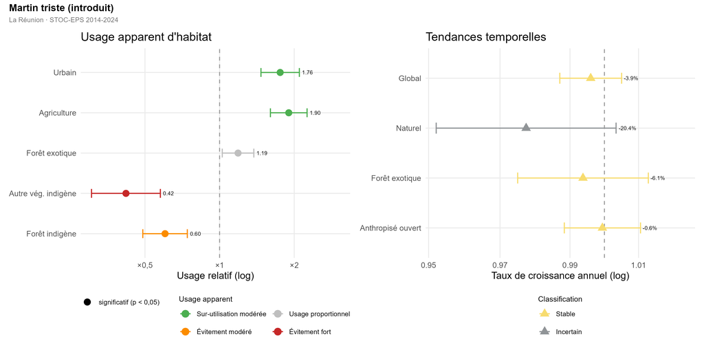

### 5.16 Busard de Maillard — Incertain (-4.7% global)

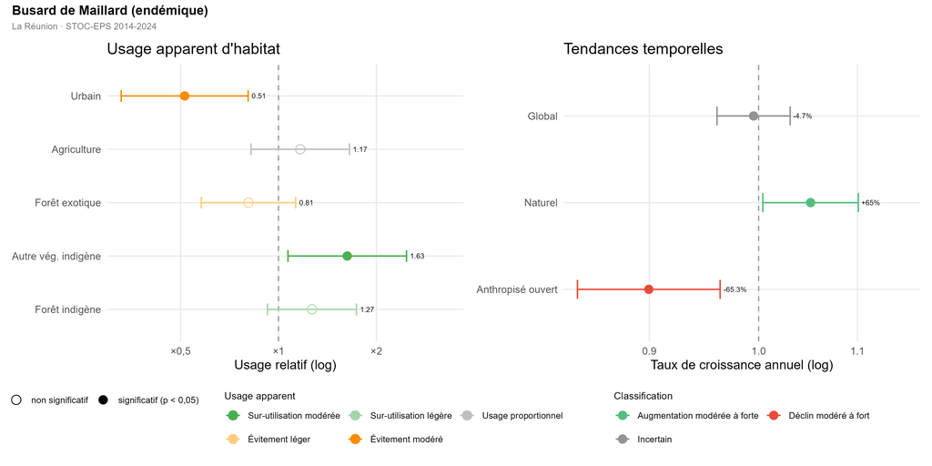

### 5.17 Hémipode de Madagascar — Incertain (-26.1% global)

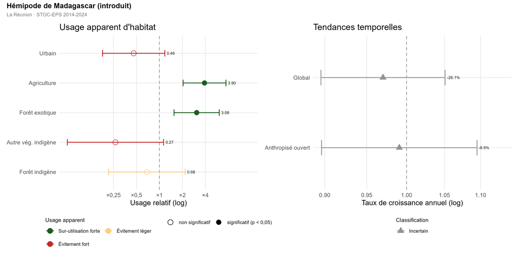

## 6 Espèces écartées de l’analyse d’usage

| Espèce | Groupe | Motif |
| --- | --- | --- |
| Mainate religieux | Introduits | 0.2 sites/an < 5 ET 1 hab < 2 |
| Francolin gris | Introduits | 0.3 sites/an < 5 |
| Perdicule rousse-gorge | Introduits | 0.3 sites/an < 5 |
| Serin du Mozambique | Introduits | 0.3 sites/an < 5 |
| Serin du Cap | Introduits | 0.4 sites/an < 5 |
| Caille peinte | Introduits | 0.5 sites/an < 5 |
| Héron strié | Natifs | 0.6 sites/an < 5 |
| Tourterelle rieuse | Introduits | 0.6 sites/an < 5 |
| Veuve dominicaine | Introduits | 0.6 sites/an < 5 |
| Travailleur à bec rouge | Introduits | 1.0 sites/an < 5 |
| Echenilleur de La Réunion | Natifs | 1.1 sites/an < 5 ET 1 hab < 2 |
| Perdrix de Madagascar | Introduits | 1.5 sites/an < 5 |
| Coq bankiva | Introduits | 1.6 sites/an < 5 |
| Gallinule poule d'eau | Natifs | 2.0 sites/an < 5 |
| Faisan de Colchide | Introduits | 2.2 sites/an < 5 |
| Léiothrix jaune | Introduits | 2.6 sites/an < 5 |
| Caille des blés | Introduits | 3.2 sites/an < 5 |
| Capucin damier | Introduits | 3.2 sites/an < 5 |
| Hirondelle de Bourbon | Natifs | fourrageur aerien/marin - usage non capte au point |
| Phaéton à bec jaune | Natifs | fourrageur aerien/marin - usage non capte au point |
| Salangane des Mascareignes | Natifs | fourrageur aerien/marin - usage non capte au point |

## 7 Conclusion

Sur 2014-2024, les **espèces introduites** déclinent nettement (-33.5 % global, et ce **dans tous les milieux**, avec un déclin plus marqué là où elles sont le plus présentes (milieux anthropisés et forêt exotique). Les **espèces natives** restent globalement **stables** (-5.6 % global), et se maintiennent le mieux dans les milieux naturels, leur habitat d’usage préférentiel.

**NoteLimites**

- **Indices apparents** : sans correction de détectabilité (1 passage/an, pas d’information de distance), ni l’usage ni la tendance ne sont des mesures de population au sens strict.
- **Forte hétérogénéité inter-espèces** (I² élevés) : les résultats de groupe résument des espèces contrastées.
- **Espèces grégaires** (tisserin, astrild…) : les comptages en colonies gonflent la variance (précision optimiste), sans biaiser la direction de l’usage.
- **Strate « forêt exotique »** : la plus mince, tendances moins précises.
- **Croisement usage ↔︎ tendance** : descriptif, non causal.

### 7.1 Hypothèses

- Déclin des introduits : réduction des ressources (graminées, herbicides), urbanisation des zones agricoles, régulation post-expansion, pathogènes.
- Maintien des natifs en milieu naturel : refuge relatif face à l’anthropisation.